# Task 20

Thorn Thaler - thorn.thaler@thothal.at<

2025-12-15

# 1 Setup

## 1.1 Libraries

```r
library(httr)
library(xml2)
library(magrittr)
library(dplyr)
library(purrr)
library(stringr)
library(igraph)
library(collections)
```

## 1.2 Retrieve Data from `AoC`

```r
session_cookie <- set_cookies(session = keyring::key_get("AoC-GitHub-Cookie"))
base_url <- paste0("https://adventofcode.com/", params$year, "/day/", params$task_nr)
puzzle <- GET(base_url,
              session_cookie) %>%
  content(encoding = "UTF-8") %>%
  xml_find_all("///article") %>%
  lapply(as.character)

parse_puzzle_data <- function(text_block = readClipboard()) {
  if (length(text_block) == 1L) {
    text_block <- text_block %>%
      str_split("\n") %>%
      extract2(1L) %>%
      keep(nzchar)
  }
  maze <- text_block %>%
    str_split("") %>%
    do.call(rbind, .)
  n <- nrow(maze)
  m <- ncol(maze)
  hole <- apply(maze, 1L, \(r) sum(r %in% c(".", "#")))
  rng <- range(hole)
  hole_rows <- which(!hole %in% rng) %>%
    range()
  row_idx <- c(1L, hole_rows[1L], hole_rows[2L] - 1L, n - 1L)
  rows <- apply(maze[row_idx, ], 1L, str_which, "[A-Z]")

  hole <- apply(maze, 2L, \(r) sum(r %in% c(".", "#")))
  rng <- range(hole)
  hole_cols <- which(!hole %in% rng) %>%
    range()
  col_idx <- c(1L, hole_cols[1L],hole_cols[2L] - 1L, m - 1L)
  cols <- apply(maze[, col_idx], 2L, str_which, "[A-Z]")
  offset <- 1L
  for (ri in seq_along(row_idx)) {
    i <- row_idx[ri]
    ci <- rows[[ri]]
    maze[i + offset, ci] <- apply(maze[seq(i, length.out = 2L), ci], 2L,
                                  paste0, collapse = "")
    maze[i + offset, ci - 1L] <- "#"
    maze[i + offset, ci + 1L] <- "#"
    offset <- (offset + 1L) %% 2L
    maze[i + offset, ci] <- "#"
    maze[i + offset, ci - 1L] <- "#"
    maze[i + offset, ci + 1L] <- "#"
  }
  for (ci in seq_along(col_idx)) {
    j <- col_idx[ci]
    ri <- cols[[ci]]
    maze[ri, j + offset] <- apply(maze[ri, seq(j, length.out = 2L)], 1L,
                                  paste0, collapse = "")
    maze[ri - 1L, j + offset] <- "#"
    maze[ri + 1L, j + offset] <- "#"
    offset <- (offset + 1L) %% 2L
    maze[ri, j + offset] <- "#"
    maze[ri - 1L, j + offset] <- "#"
    maze[ri + 1L, j + offset] <- "#"
  }
  ## recode portals to 1 LETTER
  all_portals <- str_extract(maze, "..") %>%
    na.omit() %>%
    unique() %>%
    sort()
  lkp <- c(LETTERS, letters[seq(1L, length.out = length(all_portals) - 26L)]) %>%
    set_names(all_portals) %>%
    c("." = ".", " " = " ", "#" = "#", .)
  maze[] <- lkp[c(maze)]
  warp <- map(lkp[-(1:3)], function(ptl) {
    which(maze == ptl, arr.ind = TRUE)
  }) %>%
    set_names(lkp[-(1:3)])
  structure(maze, class = "maze", start = "A", goal = tail(lkp, 1L), warp = warp)
}

puzzle_data <- local({
  GET(paste0(base_url, "/input"),
      session_cookie) %>%
    content(encoding = "UTF-8") %>%
    parse_puzzle_data()
})
```

# 2 Puzzle Day 20

## 2.1 Part 1

### 2.1.1 Description

## — Day 20: Donut Maze —

You notice a strange pattern on the surface of Pluto and land nearby to get a closer look. Upon closer inspection, you realize you’ve come across one of the famous space-warping mazes of the long-lost Pluto civilization!

Because there isn’t much space on Pluto, the civilization that used to live here thrived by inventing a method for folding spacetime. Although the technology is no longer understood, mazes like this one provide a small glimpse into the daily life of an ancient Pluto citizen.

This maze is shaped like a [donut](https://en.wikipedia.org/wiki/Torus). Portals along the inner and outer edge of the donut can instantly teleport you from one side to the other. For example:

```
         A
         A
  #######.#########
  #######.........#
  #######.#######.#
  #######.#######.#
  #######.#######.#
  #####  B    ###.#
BC...##  C    ###.#
  ##.##       ###.#
  ##...DE  F  ###.#
  #####    G  ###.#
  #########.#####.#
DE..#######...###.#
  #.#########.###.#
FG..#########.....#
  ###########.#####
             Z
             Z
```

This map of the maze shows solid walls (`#`) and open passages (`.`). Every maze on Pluto has a start (the open tile next to `AA`) and an end (the open tile next to `ZZ`). Mazes on Pluto also have portals; this maze has three pairs of portals: `BC`, `DE`, and `FG`. When on an open tile next to one of these labels, a single step can take you to the other tile with the same label. (You can only walk on `.` tiles; labels and empty space are not traversable.)

One path through the maze doesn’t require any portals. Starting at `AA`, you could go down 1, right 8, down 12, left 4, and down 1 to reach `ZZ`, a total of 26 steps.

However, there is a shorter path: You could walk from `AA` to the inner `BC` portal (4 steps), warp to the outer `BC` portal (1 step), walk to the inner `DE` (6 steps), warp to the outer `DE` (1 step), walk to the outer `FG` (4 steps), warp to the inner `FG` (1 step), and finally walk to `ZZ` (6 steps). In total, this is only *23* steps.

Here is a larger example:

```
                   A
                   A
  #################.#############
  #.#...#...................#.#.#
  #.#.#.###.###.###.#########.#.#
  #.#.#.......#...#.....#.#.#...#
  #.#########.###.#####.#.#.###.#
  #.............#.#.....#.......#
  ###.###########.###.#####.#.#.#
  #.....#        A   C    #.#.#.#
  #######        S   P    #####.#
  #.#...#                 #......VT
  #.#.#.#                 #.#####
  #...#.#               YN....#.#
  #.###.#                 #####.#
DI....#.#                 #.....#
  #####.#                 #.###.#
ZZ......#               QG....#..AS
  ###.###                 #######
JO..#.#.#                 #.....#
  #.#.#.#                 ###.#.#
  #...#..DI             BU....#..LF
  #####.#                 #.#####
YN......#               VT..#....QG
  #.###.#                 #.###.#
  #.#...#                 #.....#
  ###.###    J L     J    #.#.###
  #.....#    O F     P    #.#...#
  #.###.#####.#.#####.#####.###.#
  #...#.#.#...#.....#.....#.#...#
  #.#####.###.###.#.#.#########.#
  #...#.#.....#...#.#.#.#.....#.#
  #.###.#####.###.###.#.#.#######
  #.#.........#...#.............#
  #########.###.###.#############
           B   J   C
           U   P   P
```

Here, `AA` has no direct path to `ZZ`, but it does connect to `AS` and `CP`. By passing through `AS`, `QG`, `BU`, and `JO`, you can reach `ZZ` in *58* steps.

In your maze, *how many steps does it take to get from the open tile marked `AA` to the open tile marked `ZZ`?*

### 2.1.2 Solution

We solve the first part by a straight forward BFS, where we just have to make sure that entering a warp field moves the current position on the field before the warp field.

```r
print.maze <- function(x, ...) {
  apply(x, 1, paste, collapse = "") %>%
    paste(collapse = "\n") %>%
    cat()
  invisible(x)
}

find_shortest_path <- function(maze = puzzle_data) {
  dir <- rbind(
    "^" = c(-1L, 0L),
    ">" = c(0L, 1L),
    "v" = c(1L, 0L),
    "<" = c(0L, -1L)
  )

  warp <- attr(maze, "warp")
  start <- attr(maze, "start")
  goal <- attr(maze, "goal")

  walk_out <- function(pos) {
    for (i in seq_len(nrow(dir))) {
      new_pos <- pos + dir[i, , drop = FALSE]
      if (maze[new_pos] == ".") {
        return(new_pos)
      }
    }
  }
  n <- nrow(maze)
  m <- ncol(maze)
  dist <- matrix(-1L, n, m)
  start_pos <- which(maze == start, arr.ind = TRUE)
  dist[start_pos] <- 0L
  start_pos <- walk_out(start_pos)
  dist[start_pos] <- 0L
  queue <- matrix(NA_integer_, n * m, 2L)
  head_ptr <- tail_ptr <- 1L
  queue[head_ptr, ] <- start_pos
  while (head_ptr <= tail_ptr) {
    cur_pos <- queue[head_ptr, , drop = FALSE]
    head_ptr <- head_ptr + 1L
    nbs <- t(t(dir) + c(cur_pos))
    valid_nbs <- between(nbs[, 1L], 1L, n) &
      between(nbs[, 2L], 1L, m) &
      !maze[nbs] %in% c(" ", "#") &
      dist[nbs] == -1L
    nbs <- nbs[valid_nbs, , drop = FALSE]
    for (i in seq_len(nrow(nbs))) {
      nb <- nbs[i, , drop = FALSE]
      if (maze[nb] == goal) {
        return(dist[cur_pos])
      } else if (maze[nb] %in% names(warp)) {
        # warp
        targets <- warp[[maze[nb]]]
        dist[nb] <- dist[cur_pos]
        for (j in seq_len(nrow(targets))) {
          target <- targets[j, , drop = FALSE]
          if (!all(target == nb)) {
            dist[target] <- dist[cur_pos]
            nb <- walk_out(target)
            break
          }
        }
      }
      dist[nb] <- dist[cur_pos] + 1L
      tail_ptr <- tail_ptr + 1L
      queue[tail_ptr, ] <- nb
    }
  }
  NA_integer_
}

find_shortest_path(puzzle_data)
```

```
## [1] 636
```

## 2.2 Part 2

### 2.2.1 Description

## — Part Two —

Strangely, the exit isn’t open when you reach it. Then, you remember: the ancient Plutonians were famous for building *recursive spaces*.

The marked connections in the maze aren’t portals: they *physically connect* to a larger or smaller copy of the maze. Specifically, the labeled tiles around the inside edge actually connect to a smaller copy of the same maze, and the smaller copy’s inner labeled tiles connect to yet a *smaller* copy, and so on.

When you enter the maze, you are at the outermost level; when at the outermost level, only the outer labels `AA` and `ZZ` function (as the start and end, respectively); all other outer labeled tiles are effectively walls. At any other level, `AA` and `ZZ` count as walls, but the other outer labeled tiles bring you one level outward.

Your goal is to find a path through the maze that brings you back to `ZZ` at the outermost level of the maze.

In the first example above, the shortest path is now the loop around the right side. If the starting level is `0`, then taking the previously-shortest path would pass through `BC` (to level `1`), `DE` (to level `2`), and `FG` (back to level `1`). Because this is not the outermost level, `ZZ` is a wall, and the only option is to go back around to `BC`, which would only send you even deeper into the recursive maze.

In the second example above, there is no path that brings you to `ZZ` at the outermost level.

Here is a more interesting example:

```
             Z L X W       C
             Z P Q B       K
  ###########.#.#.#.#######.###############
  #...#.......#.#.......#.#.......#.#.#...#
  ###.#.#.#.#.#.#.#.###.#.#.#######.#.#.###
  #.#...#.#.#...#.#.#...#...#...#.#.......#
  #.###.#######.###.###.#.###.###.#.#######
  #...#.......#.#...#...#.............#...#
  #.#########.#######.#.#######.#######.###
  #...#.#    F       R I       Z    #.#.#.#
  #.###.#    D       E C       H    #.#.#.#
  #.#...#                           #...#.#
  #.###.#                           #.###.#
  #.#....OA                       WB..#.#..ZH
  #.###.#                           #.#.#.#
CJ......#                           #.....#
  #######                           #######
  #.#....CK                         #......IC
  #.###.#                           #.###.#
  #.....#                           #...#.#
  ###.###                           #.#.#.#
XF....#.#                         RF..#.#.#
  #####.#                           #######
  #......CJ                       NM..#...#
  ###.#.#                           #.###.#
RE....#.#                           #......RF
  ###.###        X   X       L      #.#.#.#
  #.....#        F   Q       P      #.#.#.#
  ###.###########.###.#######.#########.###
  #.....#...#.....#.......#...#.....#.#...#
  #####.#.###.#######.#######.###.###.#.#.#
  #.......#.......#.#.#.#.#...#...#...#.#.#
  #####.###.#####.#.#.#.#.###.###.#.###.###
  #.......#.....#.#...#...............#...#
  #############.#.#.###.###################
               A O F   N
               A A D   M
```

One shortest path through the maze is the following:

- Walk from `AA` to `XF` (16 steps)
- Recurse into level 1 through `XF` (1 step)
- Walk from `XF` to `CK` (10 steps)
- Recurse into level 2 through `CK` (1 step)
- Walk from `CK` to `ZH` (14 steps)
- Recurse into level 3 through `ZH` (1 step)
- Walk from `ZH` to `WB` (10 steps)
- Recurse into level 4 through `WB` (1 step)
- Walk from `WB` to `IC` (10 steps)
- Recurse into level 5 through `IC` (1 step)
- Walk from `IC` to `RF` (10 steps)
- Recurse into level 6 through `RF` (1 step)
- Walk from `RF` to `NM` (8 steps)
- Recurse into level 7 through `NM` (1 step)
- Walk from `NM` to `LP` (12 steps)
- Recurse into level 8 through `LP` (1 step)
- Walk from `LP` to `FD` (24 steps)
- Recurse into level 9 through `FD` (1 step)
- Walk from `FD` to `XQ` (8 steps)
- Recurse into level 10 through `XQ` (1 step)
- Walk from `XQ` to `WB` (4 steps)
- Return to level 9 through `WB` (1 step)
- Walk from `WB` to `ZH` (10 steps)
- Return to level 8 through `ZH` (1 step)
- Walk from `ZH` to `CK` (14 steps)
- Return to level 7 through `CK` (1 step)
- Walk from `CK` to `XF` (10 steps)
- Return to level 6 through `XF` (1 step)
- Walk from `XF` to `OA` (14 steps)
- Return to level 5 through `OA` (1 step)
- Walk from `OA` to `CJ` (8 steps)
- Return to level 4 through `CJ` (1 step)
- Walk from `CJ` to `RE` (8 steps)
- Return to level 3 through `RE` (1 step)
- Walk from `RE` to `IC` (4 steps)
- Recurse into level 4 through `IC` (1 step)
- Walk from `IC` to `RF` (10 steps)
- Recurse into level 5 through `RF` (1 step)
- Walk from `RF` to `NM` (8 steps)
- Recurse into level 6 through `NM` (1 step)
- Walk from `NM` to `LP` (12 steps)
- Recurse into level 7 through `LP` (1 step)
- Walk from `LP` to `FD` (24 steps)
- Recurse into level 8 through `FD` (1 step)
- Walk from `FD` to `XQ` (8 steps)
- Recurse into level 9 through `XQ` (1 step)
- Walk from `XQ` to `WB` (4 steps)
- Return to level 8 through `WB` (1 step)
- Walk from `WB` to `ZH` (10 steps)
- Return to level 7 through `ZH` (1 step)
- Walk from `ZH` to `CK` (14 steps)
- Return to level 6 through `CK` (1 step)
- Walk from `CK` to `XF` (10 steps)
- Return to level 5 through `XF` (1 step)
- Walk from `XF` to `OA` (14 steps)
- Return to level 4 through `OA` (1 step)
- Walk from `OA` to `CJ` (8 steps)
- Return to level 3 through `CJ` (1 step)
- Walk from `CJ` to `RE` (8 steps)
- Return to level 2 through `RE` (1 step)
- Walk from `RE` to `XQ` (14 steps)
- Return to level 1 through `XQ` (1 step)
- Walk from `XQ` to `FD` (8 steps)
- Return to level 0 through `FD` (1 step)
- Walk from `FD` to `ZZ` (18 steps)

This path takes a total of *396* steps to move from `AA` at the outermost layer to `ZZ` at the outermost layer.

In your maze, when accounting for recursion, *how many steps does it take to get from the open tile marked `AA` to the open tile marked `ZZ`, both at the outermost layer?*

### 2.2.2 Solution

For the second part we use an A*-algorithm. For this we first calculate the distances from each warp point to all its reachable other warp points. As the position (inner vs outer) of the warp points becomes important now, we rename the warp points and add suffixes `_i` and `_o` for **i**nner and **o**uter warp points respectively.

```r
refactor_maze <- function(maze) {
  n <- nrow(maze)
  m <- ncol(maze)
  is_outer <- function(pos) {
    pos[, 1L] %in% c(2L, n - 1) |
      pos[, 2L] %in% c(2L, m - 1)
  }
  start <- attr(maze, "start")
  goal <- attr(maze, "goal")
  warp <- attr(maze, "warp")
  iwalk(warp, function(pos, wp) {
    new_wp <- paste0(wp, if_else(is_outer(pos), "_o", "_i"))
    maze[pos] <<- new_wp
  })
  warp <- str_extract(maze, "^._[io]$")
  maze <- structure(c(maze),
                    dim = dim(maze),
                    warp = warp[!is.na(warp)],
                    start = paste0(start, "_o"),
                    goal = paste0(goal, "_o"))
  maze
}


bfs <- function(maze, start) {
  dir <- rbind(
    "^" = c(-1L, 0L),
    ">" = c(0L, 1L),
    "v" = c(1L, 0L),
    "<" = c(0L, -1L)
  )

  warp <- attr(maze, "warp")

  walk_out <- function(pos) {
    for (i in seq_len(nrow(dir))) {
      new_pos <- pos + dir[i, , drop = FALSE]
      if (maze[new_pos] == ".") {
        return(new_pos)
      }
    }
  }
  n <- nrow(maze)
  m <- ncol(maze)
  start_pos <- which(maze == start, arr.ind = TRUE)
  dist <- matrix(-1L, n, m)
  dist[start_pos] <- 0L
  start_pos <- walk_out(start_pos)
  dist[start_pos] <- 0L
  queue <- matrix(NA_integer_, n * m, 2L)
  head_ptr <- tail_ptr <- 1L
  queue[head_ptr, ] <- start_pos
  res <- tibble(from = character(0L),
                to = character(0L),
                distance = integer(0L))
  while (head_ptr <= tail_ptr) {
    cur_pos <- queue[head_ptr, , drop = FALSE]
    head_ptr <- head_ptr + 1L
    nbs <- t(t(dir) + c(cur_pos))
    valid_nbs <- between(nbs[, 1L], 1L, n) &
      between(nbs[, 2L], 1L, m) &
      !maze[nbs] %in% c(" ", "#") &
      dist[nbs] == -1L
    nbs <- nbs[valid_nbs, , drop = FALSE]
    for (i in seq_len(nrow(nbs))) {
      nb <- nbs[i, , drop = FALSE]
      if (maze[nb] %in% warp) {
        dist[nb] <- dist[cur_pos]
        res <- add_row(res,
                       from = start,
                       to = maze[nb],
                       distance = dist[cur_pos])
      }
      dist[nb] <- dist[cur_pos] + 1L
      tail_ptr <- tail_ptr + 1L
      queue[tail_ptr, ] <- nb
    }
  }
  res
}

precompute_distances <- function(maze = puzzle_data) {
  maze <- refactor_maze(maze)
  warp <- attr(maze, "warp")
  poi <- attributes(maze)[c("start", "goal")] %>%
    unlist() %>%
    unname()
  stairs <- setdiff(warp, poi) %>%
    str_remove("_[io]$") %>%
    unique() %>%
    sort()
  stairs <- tibble(from = c(paste0(stairs, "_i"),
                            paste0(stairs, "_o")),
                   to = c(paste0(stairs, "_o"),
                            paste0(stairs, "_i")),
                   distance = 1L)
  res <- map(warp, ~ bfs(maze, .x)) %>%
    list_rbind() %>%
    rbind(stairs) %>%
    filter(!((from %in% poi & str_detect(to, "_o$")) |
               (to %in% poi & str_detect(from, "_o$"))))
  attr(res, "start") <- poi[1L]
  attr(res, "goal") <- poi[2L]
  res
}

warp_distances <- precompute_distances(puzzle_data)
```

With the distances pre-computed we can plot the network:

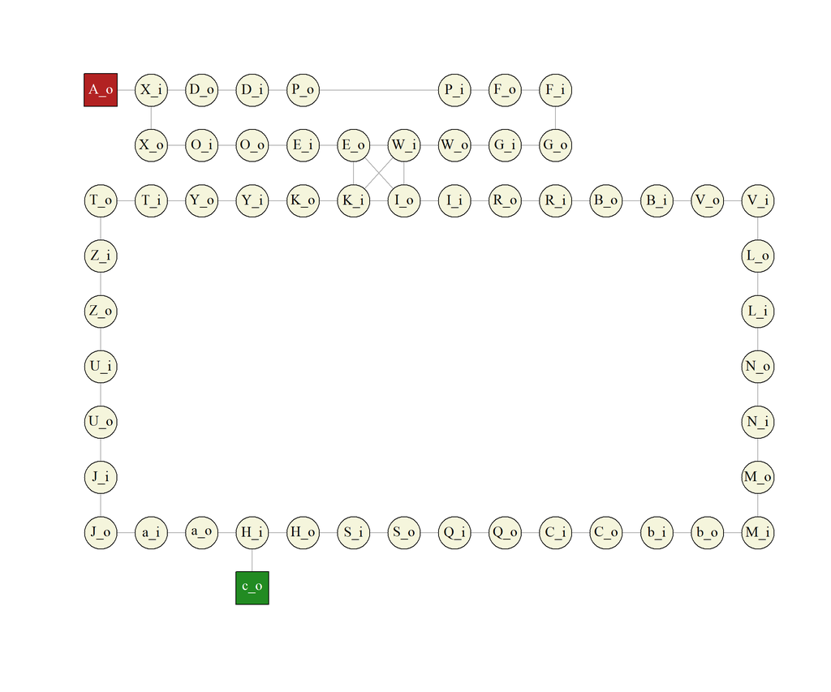

```r
compress_network <- function(dist) {
  queue <- rep(NA_character_, dist %>%
                    pull(from) %>%
                    unique() %>%
                    length())
  head_ptr <- tail_ptr <- 1L
  queue[head_ptr] <- attr(dist, "start")

  res <- dist[0L, ] %>%
    cbind(levels = integer(0L))
  skip <- tibble(from = character(0L), to = character(0L))
  while (head_ptr <= tail_ptr) {
    cur <- queue[head_ptr]
    head_ptr <- head_ptr + 1L
    cands <- dist %>%
      filter(from == cur) %>%
      anti_join(skip, c("from", "to"))
    for (i in seq_len(nrow(cands))) {
      cand <- cands %>%
        slice(i)
      weight <- cand %>%
        pull(distance)
      start <- parent <- cand %>%
        pull(from)
      kid <- cand %>%
        pull(to)
      levels <- 0L
      while (TRUE) {
        kids <- dist %>%
          filter(from == kid, to != parent)
        if (str_remove(parent, "_[io]$") == str_remove(kid, "_[io]$")) {
          if (str_detect(parent, "_i$")) {
            levels <- levels - 1L
          } else {
            levels <- levels + 1L
          }
        }

        if (nrow(kids) > 1L || nrow(kids) == 0L) {
          res <- rbind(res,
                       tibble(from = c(start, kid),
                              to = c(kid, start), distance = weight,
                              levels = c(levels, -levels)))
          skip <- rbind(skip,
                        tibble(from = c(kid, parent), to = c(parent, kid)))
          if (!kid %in% queue) {
            tail_ptr <- tail_ptr + 1L
            queue[tail_ptr] <- kid
          }
          break
        } else {
          parent <- kid
          kid <- kids %>%
            pull(to)
          weight <- weight + kids %>%
            pull(distance)
        }

      }
    }
  }
  attr(res, "start") <- attr(dist, "start")
  attr(res, "goal") <- attr(dist, "goal")
  res
}
compressed_distances <- compress_network(warp_distances)
```

This compressed graph looks like this (the edges are labeled by the distance / level change):

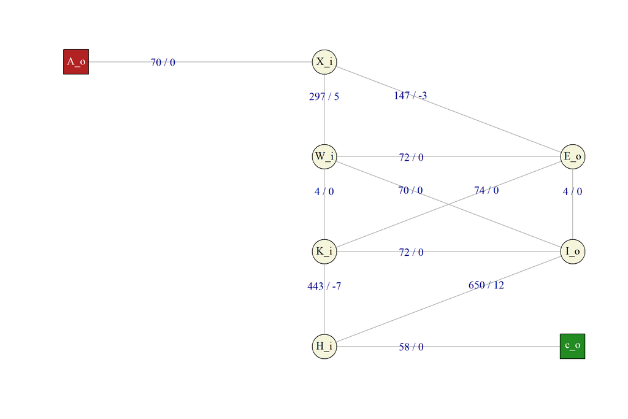

We just have to be careful to not allow using the path `X_i -> W_i` on the ground level of the maze, as it would pass through `D_o` which is not existing on the ground floor. Likewise we must not use the edge `H_i -> c_o` on any other floor than the ground floor. In general, we must not use edges which would lead to a non-existing floor > 0 (`A_o -> X_i -> E_o -> W_i -> X_i` for example). This rule also ensures that we do not use the illegal edge on level 0. The special rule for entering the exit (`H_i -> c_o`) must be checked however on each turn.

With this setup we are ready to implement an A-Star search where the current portal and the current floor form the state. We use the current floor times the minimum distance as heuristic `h` (it will never overestimate the real costs).

```r
a_star_search <- function(dist) {
  pq <- priority_queue()
  costs <- new.env(parent = emptyenv())
  d_min <- dist %>%
    pull(distance) %>%
    min()
  h <- function(state) {
    abs(state$level) * d_min
  }
  get_key <- function(state) {
    sprintf("%s_%d", state$pos, state$level)
  }

  goal  <- attr(dist, "goal")
  start <- list(pos = attr(dist, "start"), level = 0L)
  start_key <- get_key(start)

  costs[[start_key]] <- 0
  pq$push(start, -(costs[[start_key]] + h(start)))

  while(pq$size() > 0) {
    cur <- pq$pop()
    cur_key <- get_key(cur)
    g_cur <- costs[[cur_key]]

    if (cur$pos == goal) {
      return(costs[[cur_key]])
    }

    cands <- dist %>%
      mutate(new_level = cur$level + levels) %>%
      filter(from == cur$pos, new_level <= 0L)
    if (cur$level < 0L) {
      ## we must not use H_i -> c_o on any level other than 0
      cands <- cands %>%
        filter(!(from == "H_i" & to == "c_o"))
    }
    for (i in seq_len(nrow(cands))) {
      to_node   <- cands$to[i]
      new_level <- cands$new_level[i]
      dis       <- cands$distance[i]

      new_state <- list(pos = to_node, level = new_level)
      new_key   <- get_key(new_state)
      if (!exists(new_key, costs, inherits = FALSE)) {
        costs[[new_key]] <- Inf
      }
      tentative_g <- g_cur + dis
      if (tentative_g < costs[[new_key]]) {
        costs[[new_key]] <- tentative_g
        f <- -(tentative_g + h(new_state))
        pq$push(new_state, f)
      }
    }
  }
}
a_star_search(compressed_distances)
```

```
## [1] 7248
```